# Mapeamento Político do Setor de Saúde no Brasil

Renan Magalhães

```r
library(tufte)
```

O seguinte trabalho procura contribuir com as ações do IEPS em construir uma agenda para o setor saúde e para o futuro do SUS no pós-pandemia, a Agenda 2022. Para isso, procuramos construir um mapeamento político dos atores do setor saúde no Brasil, vislumbrando estratégias de engajamento.

### Metodologia

O trabalho partiu de uma busca inicial da compreensão dos diferentes Macrotemas propostos para a Agenda 2022 e o perfil dos atores ali envolvidos. Os Macrotemas são:

- 1.1. Modelos de Gestão
- 1.2. Integração Público Privada
- 1.3 Financiamento do SUS
- 2.1. Recursos humanos no sistema de saúde
- 2.2. Infraestrutura em saúde
- 2.3. Tecnologia e Inovação em Saúde
- 3.1 Regionalização
- 3.2 Competências interfederativas
- 3.3. Pacto Federativo e constituição das redes de atenção à saúde
- 4.1. Atenção Primária
- 5.1. Condições de vida e saúde
- 5.2. Equidade e inclusão de grupos sociais em saúde
- 5.3 Saúde mental
- 5.4. Saúde e meio ambiente

Considerando o limite temporal desse trabalho, mapeamentos anteriores realizados pelo IEPS e nas ações futuras da organização, decidimos por concentrar nossos esforços em um primeiro momento nos Macrotemas 4 e 5 e seus subtemas:

- 4.1.1 Promoção da Saúde
- 4.1.2 Fortalecimento das vigilâncias em saúde
- 4.1.3 Expansão da estratégia Saúde da Família
- 5.2.1 Saúde da população negra
- 5.2.2 Saúde dos povos indígenas e quilombolas
- 5.2.3 Saúde da população LGBT
- 5.2.4 Saúde da Pessoa com Deficiência
- 5.2.1 Políticas públicas de saúde mental
- 5.2.2. Desafios para o futuro das políticas de saúde mental
- 5.3.1. Pandemias e degradação do meio ambiente
- 5.3.2. Desafios da saúde socioambiental

A partir dessa delimitação dos temas observados e sua melhor compreensão, buscou-se compreender os atores e intituições relacionados com esses macro e microtemas em um processo de identificação, análise política (análise de stakeholders) e análise dos vínculos institucionais (network analsyis).

### Identificação

A Tabela de identificação dos atores é a primeira etapa desse mapeamento, funcionando como um banco de dados dos atores a serem analisados posteriormente. Para cada entrada no banco de dados foi criado um ID para as análises futuras, facilitando os processos de joint e merging tables. A tabela ainda paresenta o nome do órgão, a sigla, a esfera administrativa, o nome da chefia responsável, contatos, a abrangência espacial e a natureza do ator (administraçõa pública, setor privado, terceiro setor, etc.).

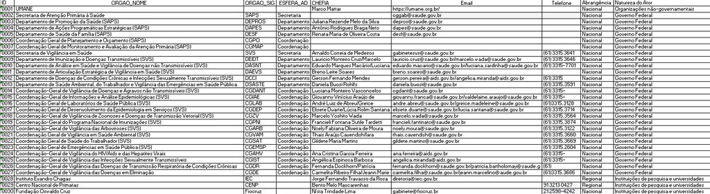

Visualização do Tabela de Identificação

### Análise de Stakeholders

A segunda tabela da base de dados consiste em uma breve análise de stakeholders dos atores mapeados. A análise procura responder as seguintes perguntas:

- Que recursos este ator possui?
- O que ele/a vislumbra de importante ao relacionar-se com o IEPS/Agenda 2022?
- Qual a importância para o IEPS no relacionamento com ele/a?

A análise procura apresentar características básicas de cada ator mapeado de forma a facilitar o processo de identificação destes. Com isso, a análise pode servir como um guia para as atividades de formação de comissão dos trabalhos da Agenda 2022 ou de outras ações do IEPS, apresentando uma ideia inicial de quem é o ator com quem a instituição está lidando, suas ações e projetos, seus interesses em relacionar-se com o IEPS e sua importância no avanço das discussões da Agenda 2022 e na composição dos grupos de trabalho.

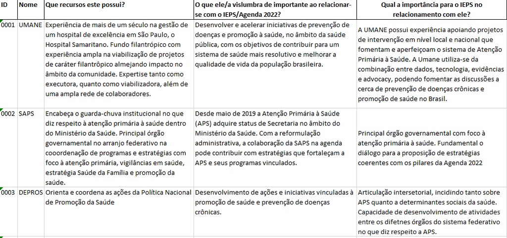

Visualização do Tabela de Análise de Stakeholders

### Network Analysis

A seguir apresentamos uma visão geral do mapeamento:

```r
library(igraph)
library(readr)
library(tidyr)
library(readxl)
library(ggraph)
library(ggplot2)
library(dplyr)
library(Rcpp)
library(visNetwork)
library(extrafont)
```

```r
nodes <- read_excel("IDS.xlsx")
nodes
```

```
## # A tibble: 715 x 3
##    id    name                                               type
##    <chr> <chr>                                              <chr>
##  1 0001  UMANE                                              Organizações não-go~
##  2 0002  Secretaria de Atenção Primária à Saúde             Governos
##  3 0003  Departamento de Promoção da Saúde (SAPS)           Governos
##  4 0004  Departamento de Ações Programáticas Estratégicas ~ Governos
##  5 0005  Departamento de Saúde da Família (SAPS)            Governos
##  6 0006  Coordenação Geral de Planejamento e Orçamento (SA~ Governos
##  7 0007  Coordenação Geral de Monitoramento e Avaliação da~ Governos
##  8 0008  Secretaria de Vigilância em Saúde                  Governos
##  9 0009  Departamento de Imunização e Doenças Transmissíve~ Governos
## 10 0010  Departamento de Análise em Saúde e Vigilância de ~ Governos
## # ... with 705 more rows
```

```r
ties <- read_excel("Relacionamentos.xlsx")
ties
```

```
## # A tibble: 728 x 3
##    from  to    weight
##    <chr> <chr>  <dbl>
##  1 0001  0169       1
##  2 0001  0170       1
##  3 0001  0171       1
##  4 0001  0077       1
##  5 0001  0033       1
##  6 0001  0172       1
##  7 0001  0173       1
##  8 0001  0174       1
##  9 0001  0175       1
## 10 0001  0082       1
## # ... with 718 more rows
```

```
## IGRAPH 32e0c9f UNWB 715 728 --
## + attr: name (v/c), type (v/c), weight (e/n)
## + edges from 32e0c9f (vertex names):
##  [1] UMANE--Tellus            UMANE--Instituto Pensi   UMANE--AME sua mente
##  [4] UMANE--Artemisia         UMANE--Fundação Butantan UMANE--Horas da Vida
##  [7] UMANE--Ceap/USP          UMANE--Mossa             UMANE--Nupens Usp
## [10] UMANE--IEPS              UMANE--CLP
## + ... omitted several edges
```

[figure not shown]

```r
g <- graph_from_data_frame(ties, directed = FALSE, vertices = nodes)
g
```

A partir da construção dessa rede de atores, com o código fonte, é possível realizar alterações e filtros, exibindo por tipo de ator mapeado ou pelo tipo de conexão entre eles. Da mesma forma, a network analysis nos permite realizar inferências sobre os atores que a visualização por si só não permite.

### Medidas de Centralidade

A partir de medidas de centralidade, podemos calcular as instituições e atores políticos com maior número de conexões. Aqui utilizamos a mais simples e popular medida de centralidade na ciência de network - grau de centralidade. No contexto desse dataset, isso significa o número de atores políticos que cada ator político está conectado.

```r
nodes_with_centrality <- nodes %>%
  mutate(degree = degree(g)) %>%
  arrange(desc(degree))

nodes_with_centrality
```

```
## # A tibble: 715 x 4
##    id    name                             type                            degree
##    <chr> <chr>                            <chr>                            <dbl>
##  1 0075  Ibirapitanga                     Organizações não-governamentais     84
##  2 0034  Associação Brasileira de Saúde ~ Movimentos Sociais e Órgãos de~     82
##  3 0035  Congresso Brasileiro de Epidemi~ Instituições de pesquisa e uni~     70
##  4 0036  Rede de Pesquisa em Atenção Pri~ Instituições de pesquisa e uni~     47
##  5 0078  Todos pela saúde                 Organizações não-governamentais     46
##  6 0079  ACT - Promoção da Saúde          Organizações não-governamentais     39
##  7 0001  UMANE                            Organizações não-governamentais     36
##  8 0033  Fundação Butantan                Instituições de pesquisa e uni~     33
##  9 0076  Desiderata                       Organizações não-governamentais     32
## 10 0008  Secretaria de Vigilância em Saú~ Governos                            24
## # ... with 705 more rows
```

A partir dessa base inicial, é possível filtrar conforme o tipo de organização/ator político.

```r
ngo <- nodes_with_centrality %>%
  filter(type == "Organizações não-governamentais")

ngo
```

```
## # A tibble: 80 x 4
##    id    name                    type                            degree
##    <chr> <chr>                   <chr>                            <dbl>
##  1 0075  Ibirapitanga            Organizações não-governamentais     84
##  2 0078  Todos pela saúde        Organizações não-governamentais     46
##  3 0079  ACT - Promoção da Saúde Organizações não-governamentais     39
##  4 0001  UMANE                   Organizações não-governamentais     36
##  5 0076  Desiderata              Organizações não-governamentais     32
##  6 0072  Impulso                 Organizações não-governamentais     23
##  7 0080  Projeto Saúde e Alegria Organizações não-governamentais     21
##  8 0082  IEPS                    Organizações não-governamentais     19
##  9 0073  Vital Strategies        Organizações não-governamentais     16
## 10 0081  Arapyaú                 Organizações não-governamentais     15
## # ... with 70 more rows
```

```r
pessoas <- nodes_with_centrality %>%
  filter(type == "Pesquisadores, Membros de Conselho e Chefias")

pessoas
```

```
## # A tibble: 357 x 4
##    id    name                          type                               degree
##    <chr> <chr>                         <chr>                               <dbl>
##  1 0469  Márcia Castro                 Pesquisadores, Membros de Conselh~      3
##  2 0640  Antônio Drauzio Varella       Pesquisadores, Membros de Conselh~      3
##  3 0090  Marcelo Yoshito Wada          Pesquisadores, Membros de Conselh~      2
##  4 0092  Luciana Monteiro Vasconcelos~ Pesquisadores, Membros de Conselh~      2
##  5 0121  Dimas Tadeu Covas             Pesquisadores, Membros de Conselh~      2
##  6 0122  Rui Curi                      Pesquisadores, Membros de Conselh~      2
##  7 0231  Reinaldo Noboru Sato          Pesquisadores, Membros de Conselh~      2
##  8 0243  Gonzalo Vecina Neto           Pesquisadores, Membros de Conselh~      2
##  9 0311  Guilherme Werneck             Pesquisadores, Membros de Conselh~      2
## 10 0329  Regina Flauzino               Pesquisadores, Membros de Conselh~      2
## # ... with 347 more rows
```

Como nem todos os relacionamentos são iguais, podemos levar em consideração além do número de conexões, os atores políticos com conexões mais fortes:

```r
nodes_with_centrality_strength <- nodes %>%
  mutate(
    degree = degree(g),
    strength = strength(g)
  ) %>%
  arrange(desc(strength))

nodes_with_centrality_strength
```

```
## # A tibble: 715 x 5
##    id    name                        type                        degree strength
##    <chr> <chr>                       <chr>                        <dbl>    <dbl>
##  1 0035  Congresso Brasileiro de Ep~ Instituições de pesquisa e~     70      140
##  2 0078  Todos pela saúde            Organizações não-govername~     46      131
##  3 0034  Associação Brasileira de S~ Movimentos Sociais e Órgão~     82      104
##  4 0075  Ibirapitanga                Organizações não-govername~     84       91
##  5 0036  Rede de Pesquisa em Atençã~ Instituições de pesquisa e~     47       85
##  6 0008  Secretaria de Vigilância e~ Governos                        24       71
##  7 0033  Fundação Butantan           Instituições de pesquisa e~     33       65
##  8 0079  ACT - Promoção da Saúde     Organizações não-govername~     39       54
##  9 0080  Projeto Saúde e Alegria     Organizações não-govername~     21       54
## 10 0001  UMANE                       Organizações não-govername~     36       49
## # ... with 705 more rows
```

```r
governos <- nodes_with_centrality_strength %>%
  filter(type == "Governos")
governos
```

```
## # A tibble: 67 x 5
##    id    name                                             type   degree strength
##    <chr> <chr>                                            <chr>   <dbl>    <dbl>
##  1 0008  Secretaria de Vigilância em Saúde                Gover~     24       71
##  2 0002  Secretaria de Atenção Primária à Saúde           Gover~      6       18
##  3 0194  Ministério da Saúde                              Gover~      9       15
##  4 0048  Superintendência de Atenção Primária             Gover~     11       11
##  5 0039  Secretaria Especial de Saúde Indígena            Gover~      8        8
##  6 0047  Secretaria de Saúde do Estado do Rio de Janeiro  Gover~      6        8
##  7 0228  Governo do Estado de São Paulo                   Gover~      4        8
##  8 0009  Departamento de Imunização e Doenças Transmissí~ Gover~      3        7
##  9 0010  Departamento de Análise em Saúde e Vigilância d~ Gover~      3        7
## 10 0016  Coordenação Geral de Laboratórios de Saúde Públ~ Gover~      3        7
## # ... with 57 more rows
```

```r
ngos2 <- nodes_with_centrality_strength %>%
  filter(type == "Organizações não-governamentais")
ngos2
```

```
## # A tibble: 80 x 5
##    id    name                    type                            degree strength
##    <chr> <chr>                   <chr>                            <dbl>    <dbl>
##  1 0078  Todos pela saúde        Organizações não-governamentais     46      131
##  2 0075  Ibirapitanga            Organizações não-governamentais     84       91
##  3 0079  ACT - Promoção da Saúde Organizações não-governamentais     39       54
##  4 0080  Projeto Saúde e Alegria Organizações não-governamentais     21       54
##  5 0001  UMANE                   Organizações não-governamentais     36       49
##  6 0076  Desiderata              Organizações não-governamentais     32       49
##  7 0072  Impulso                 Organizações não-governamentais     23       36
##  8 0082  IEPS                    Organizações não-governamentais     19       33
##  9 0081  Arapyaú                 Organizações não-governamentais     15       23
## 10 0073  Vital Strategies        Organizações não-governamentais     16       20
## # ... with 70 more rows
```

### Inbetweenness

Finalmente, podemos calcular a “inbetweenness” da nossa rede.Inbetweenness, ou intermediação, pode ser definido quantidade de influência que um nó tem sobre o fluxo de informações em um gráfico. Pontos com alto indíce de betweenness pode ter considerável influência sobre uma rede por controlar o tráfego de informações entre os nós. Assim, remover um desses pontos pode romper toda a comunicação entre os pontos.

```r
dist_weight <- 1 / E(g)$weight

ties_with_betweenness <- ties %>%
  mutate(betweenness = edge_betweenness(g, weights = dist_weight))

ties_with_betweenness
```

```
## # A tibble: 728 x 4
##    from  to    weight betweenness
##    <chr> <chr>  <dbl>       <dbl>
##  1 0001  0169       1        670
##  2 0001  0170       1        670
##  3 0001  0171       1        670
##  4 0001  0077       1       6610
##  5 0001  0033       1          0
##  6 0001  0172       1        670
##  7 0001  0173       1        670
##  8 0001  0174       1        670
##  9 0001  0175       1      17502.
## 10 0001  0082       1       3087.
## # ... with 718 more rows
```

```r
ties_joined <- ties_with_betweenness %>%
  left_join(nodes_with_centrality_strength , by = c("from" = "id")) %>%
  left_join(nodes_with_centrality_strength , by = c("to" = "id"))

ties_joined
```

```
## # A tibble: 728 x 12
##    from  to    weight betweenness name.x type.x degree.x strength.x name.y
##    <chr> <chr>  <dbl>       <dbl> <chr>  <chr>     <dbl>      <dbl> <chr>
##  1 0001  0169       1        670  UMANE  Organ~       36         49 Tellus
##  2 0001  0170       1        670  UMANE  Organ~       36         49 Insti~
##  3 0001  0171       1        670  UMANE  Organ~       36         49 AME s~
##  4 0001  0077       1       6610  UMANE  Organ~       36         49 Artem~
##  5 0001  0033       1          0  UMANE  Organ~       36         49 Funda~
##  6 0001  0172       1        670  UMANE  Organ~       36         49 Horas~
##  7 0001  0173       1        670  UMANE  Organ~       36         49 Ceap/~
##  8 0001  0174       1        670  UMANE  Organ~       36         49 Mossa
##  9 0001  0175       1      17502. UMANE  Organ~       36         49 Nupen~
## 10 0001  0082       1       3087. UMANE  Organ~       36         49 IEPS
## # ... with 718 more rows, and 3 more variables: type.y <chr>, degree.y <dbl>,
## #   strength.y <dbl>
```

```r
ties_selected <- ties_joined %>%
  select(from, to, name_from = name.x, name_to = name.y, betweenness)
ties_selected
```

```
## # A tibble: 728 x 5
##    from  to    name_from name_to           betweenness
##    <chr> <chr> <chr>     <chr>                   <dbl>
##  1 0001  0169  UMANE     Tellus                   670
##  2 0001  0170  UMANE     Instituto Pensi          670
##  3 0001  0171  UMANE     AME sua mente            670
##  4 0001  0077  UMANE     Artemisia               6610
##  5 0001  0033  UMANE     Fundação Butantan          0
##  6 0001  0172  UMANE     Horas da Vida            670
##  7 0001  0173  UMANE     Ceap/USP                 670
##  8 0001  0174  UMANE     Mossa                    670
##  9 0001  0175  UMANE     Nupens Usp             17502.
## 10 0001  0082  UMANE     IEPS                    3087.
## # ... with 718 more rows
```

```r
ties_selected %>%
  # Arrange rows by descending betweenness
  arrange(desc(betweenness))
```

```
## # A tibble: 728 x 5
##    from  to    name_from               name_to                       betweenness
##    <chr> <chr> <chr>                   <chr>                               <dbl>
##  1 0035  0125  Congresso Brasileiro d~ Abrasco                            44911.
##  2 0075  0125  Ibirapitanga            Abrasco                            44058.
##  3 0036  0125  Rede de Pesquisa em At~ Abrasco                            42128.
##  4 0008  0194  Secretaria de Vigilânc~ Ministério da Saúde                37270.
##  5 0029  0008  Centro Nacional de Pri~ Secretaria de Vigilância em ~      30521.
##  6 0073  0294  Vital Strategies        universidade de são paulo - ~      30176.
##  7 0034  0294  Associação Brasileira ~ universidade de são paulo - ~      29972.
##  8 0033  0001  Fundação Butantan       UMANE                              29017.
##  9 0029  0030  Centro Nacional de Pri~ Fundação Oswaldo Cruz              28090.
## 10 0034  0030  Associação Brasileira ~ Fundação Oswaldo Cruz              27236.
## # ... with 718 more rows
```

### Conclusões

Esse trabalho pretende ser um guia para as futuras ações do IEPS, um documento a ser consultado conforme os interesses e projetos da organização, focado principalmente nas Agenda 2022.

A base de dados e o código em R permitem alterações, expansões e filtros conforme as perguntas de interesse a serem respondidas. Por isso, esse documento não pretende nesse momento apresentar uma análise do resultado do mapeamento e da network analysis aqui feita, isso por que acreditamos que ela deva responder os questionamentos conforme o interesse do IEPS em cada etapa de trabalho da Agenda 2022.

Assim, além das informações contidas na etapa inicial de análise de stakeholders, o código construído aqui tem potecial para responder perguntas como: qual o pesquisador ou membro de conselho mais influente na rede? Qual organização do terceiro setor possui maior capilaridade? Qual a distância entre o IEPS e uma organização x de interesse?

Dessa forma, o mapeamento a seguir apresentado deve ser visto não como um projeto acabado, mas sim como um guia para as ações futuras do IEPS, um instrumentos que pode ser consultado ao longo da construção da Agenda 2022. Assim, o projeto pode ser expandido conforme novos atores vão sendo descobertos - ou conforme as diferentes ações do IEPS vão expandindo sua lista de contatos.